# DavisTTT_2018_2

## Team performance summary

| id | power2drag_front | power2drag_ftp_front | percentage_ftp_front | speed (m/s) | ascent (m) | mean_turn_length | sd_turn_length |
| --- | --- | --- | --- | --- | --- | --- | --- |
| 0005 | 39.82 | 0.1291 | 0.9891 | 11.38 | 71.09 | 66.6 | 68.33 |

Note that an algorithm is used to detect the front rider, if this looks wrong, the analyses might not hold.

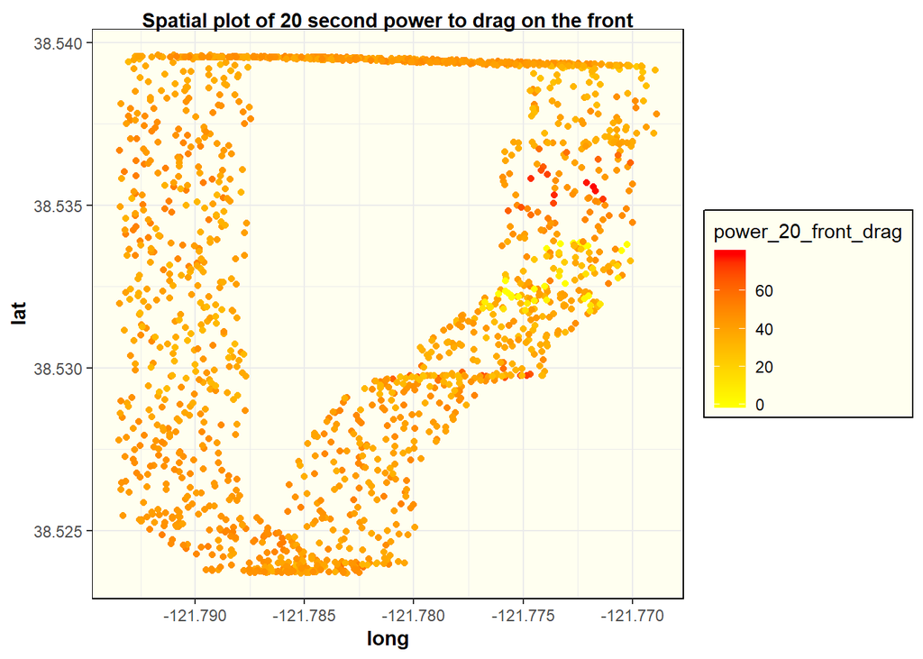

The above plot shows the spatial distribution of the 20 secondpower for the rider on the front

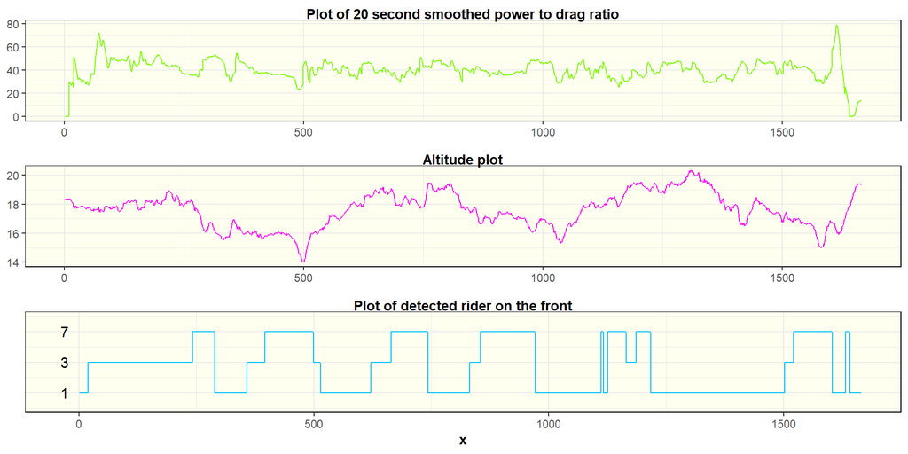

## Individual performance summary

| id | name | avg_power | norm_power | IF | TSS | avg_power2drag_front | avg_turn | total_turn | avg_norm_power_front |
| --- | --- | --- | --- | --- | --- | --- | --- | --- | --- |
| 1 | Duncan | 271.2 | 292.0 | 0.9269 | 39.74 | 40.78 | 85.56 | 770 | 319.8 |
| 3 | Quinten Williams | 294.6 | 309.0 | 1.0800 | 53.99 | 43.72 | 54.57 | 382 | 361.9 |
| 7 | Charlie Herndon | 266.0 | 277.6 | 0.8674 | 34.80 | 35.48 | 57.00 | 513 | 295.3 |

## Interpretation

The front rider identification looks about right here, with Charlie and Duncan doing the majority of the pulls, with Quinten contributing where he could. Quinten’s turns were the shortest, but most powerful, with Duncan’s turns having the next best power to drag. Using the IF we can see that Quinten managed really push himself hard, with Duncan pushing quite hard with Charlie failing to push himself that hard. Duncan took the longest turns, with Charlie’s and Quinten’s turns of comparable lenght. However Quinten took one long turn at the start and subsequently did not do many more long turns. The difference between average and normalised power on the front was similar for Duncan and Charlie, Quinten’s was slightly higher, suggesting he was more surgy while doing his turns on the front. I think the data show this was a well paced TTT, given the team makeup. Charlie could have pushed harder, perhaps with shorter turns, Quinten could have avoided the long turn at the start and contributed more throughout, with less surgy efforts on the front. Duncan could have pushed harder in the early part of the TTT with shorter turns.